# 21-01 주제분석 3주차 패키지

```python
import pandas as pd
import numpy as np

import matplotlib.pyplot as plt
import seaborn as sns

from category_encoders.cat_boost import CatBoostEncoder
import lightgbm as lgb
from lightgbm import LGBMModel,LGBMRegressor
```

```python
train = pd.read_csv('C:/Users/user/Downloads/주제분석 3주차 패키지/train.csv')
test=  pd.read_csv('C:/Users/user/Downloads/주제분석 3주차 패키지/test.csv')

train_x = train.drop(['price'], axis = 1)
train_y = train.loc[:, ['price']]
test_x = test.drop(['price'], axis = 1)
test_y = np.sqrt(test.loc[:, ['price']])

feature_list = list(train_x.columns)

CBE_encoder = CatBoostEncoder()
train_cbe = CBE_encoder.fit_transform(train_x[feature_list], train_y)
test_cbe = CBE_encoder.transform(test_x[feature_list])

best_lgbm_reg = LGBMRegressor(learning_rate = 0.3)
best_lgbm_reg.fit(train_cbe, train_y)
```

```
LGBMRegressor(learning_rate=0.3)
```

## 1. Interpretable ML

https://danbi-ncsoft.github.io/competition/2019/02/19/big-contest-2018-retrospect.html

https://christophm.github.io/interpretable-ml-book/

### 1.1 모델 불러오기

주어진 패키지를 불러오고, `lgbm.pkl`을 불러오세요.

```python
import pickle
import joblib
```

```python
file = open('lgbm.pkl', 'rb')
model = pickle.load(file)
```

### 1.2 Feature Importance 확인과 해석

- 불러온 모델에 대해 `plot_importance`함수를 통해 Feature Importance를 시각화해주세요.
- 결과에 대해 간단히 해석해주세요.

여기서 Feature Importance는 Permutation를 통한 중요도를 보는 것이 아니고, tree 모델 자체의 구성에서 어떤 변수가 지니불순도를 잘 줄였는지를 확인한 것이라고 이해해주시면 됩니다.

답:) feature importance를 보았을 때, exclusive_use_area/ dong/ apt순으로 중요도가 높게 나왔다. 하지만, 카테고리가 많은 변수들은 ‘high cardinality’ 변수들의 중요도를 더욱 부풀릴 가능성이 높을 수 있어 permutation importance방법과 함께 봐야할 것 같다.

```python
# pip install xgboost
```

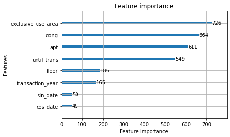

```python
lgb.plot_importance(model)
plt.show()
```

**이제는 불러온 모델 말고, `best_lgbm_reg`를 사용하세요.**

### 1.3 Randomness Control

- `random, numpy` 패키지의 난수를 42로 고정하세요.
- 더불어서 `os` 패키지의 난수도 고정해야합니다.

파이썬의 시드 고정은 R처럼 그냥 `set.seed()`한다고 해서 고정되지 않습니다. 전체 파이썬과 여러 패키지들의 randomness를 각각 고정해주어야 재현가능해집니다. 정말 귀찮고, 딥러닝의 경우 GPU를 사용할 경우 GPU의 계산과 관련된 시드를 고정하면 속도가 상당히 느려진다고 알려져 있습니다. 더불어서 재현도 100%되진 않으며 성능도 살짝 떨어진다고는 하지만, GPU를 사용하지 않는 경우에는 문제가 없고 최소한 할줄은 알아야겠죠?

더불어서 왜 저런식으로 복잡하게 구성이 되는가?에 대해 궁금할 수 있는데 찾아본 적은 없지만 아마도 `numpy`는 c++가 뒤에서 연산을 해주는 것으로 알고있고(그래서 빠름!), `random`은 그냥 파이썬이고, `os`는 우리 os를 건드리는 것이 아닐까....? 추측입니다 :)

```python
import random
import os
```

### 1.4 Permutation Feature Importance

- permutation feature importance를 계산하기 위해 `best_lgbm_reg`를 `permutation_importance`함수를 사용해 test set에 적합하세요.
- permutation feature importance를 시각화해주세요.

위의 1.2에서는 train에서 변수중요도를 보고, 지금은 test에서 봐서 좀 이상하다고 생각할수도 있습니다. 편의를 위해, 그리고 실제로 변수중요도에 대한 부분에서 어떤 set에 대해 봐야하는지가 100% 정답처럼 있는 것은 아니라고 알고 있어요.(물론 제가 틀렸을수도!) 아무튼 너무 신경쓰지말고 해주세요!

```python
from sklearn.inspection import permutation_importance
```

```python
model2 = best_lgbm_reg.fit(train_cbe, train_y)
```

```python
perm = permutation_importance(model2,test_cbe, test_y,random_state=42)
```

## permutation importance시각화

```python
best_lgbm_reg
```

```
LGBMRegressor(learning_rate=0.3)
```

```python
perm.importances
```

```
array([[-125941.51015091, -125854.55262045, -127062.48174532,
        -128155.44963936, -127041.65650271],
       [-139334.03980609, -139765.97449153, -139095.44942366,
        -139502.42074307, -139231.45401684],
       [-151206.29291632, -153669.16132659, -150523.30635838,
        -155793.2505465 , -154340.42825415],
       [ -14317.71777594,  -13522.79758775,  -13051.15945991,
         -13135.35968964,  -13359.78919325],
       [      0.        ,       0.        ,       0.        ,
              0.        ,       0.        ],
       [ -51168.05269394,  -52159.23082708,  -50925.30421382,
         -49954.84781437,  -52309.74654758],
       [   1322.10127894,    1414.62524385,    1312.69261611,
           1528.64507147,     724.10735   ],
       [    777.32993619,     960.86844498,     764.74354336,
            829.87832071,     763.13005153]])
```

```python
perm.importances_mean
```

```
array([-126811.13013175, -139385.86769624, -153106.48788039,
        -13477.3647413 ,       0.        ,  -51303.43641936,
          1260.43431207,     819.19005935])
```

```python
perm.importances_std
```

```
array([ 847.91443272,  231.92165754, 1966.79798425,  451.81849743,
          0.        ,  863.13939615,  279.2462033 ,   74.89515522])
```

```python
train_x.columns
```

```
Index(['dong', 'apt', 'exclusive_use_area', 'floor', 'transaction_year',
       'until_trans', 'sin_date', 'cos_date'],
      dtype='object')
```

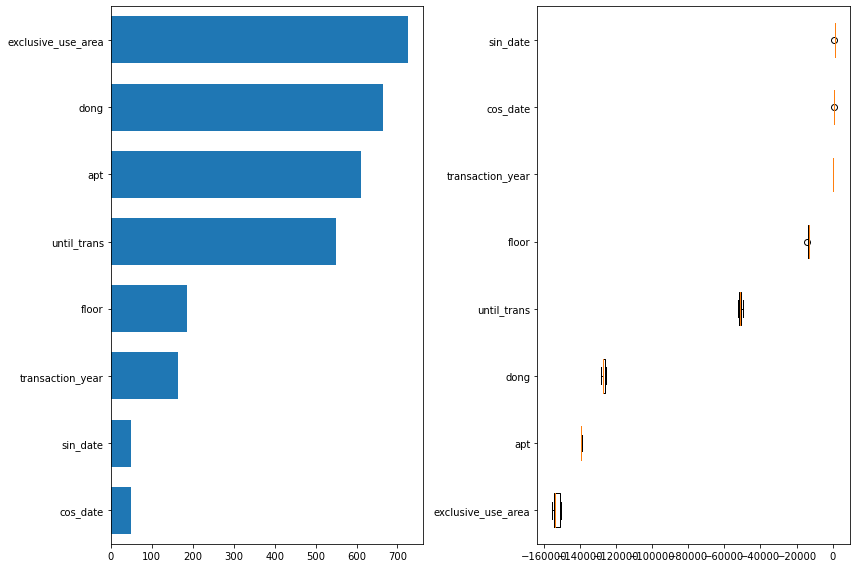

```python
perm_sorted_idx = perm.importances_mean.argsort()

tree_importance_sorted_idx = np.argsort(model2.feature_importances_)
tree_indices = np.arange(0, len(model2.feature_importances_)) + 0.5

fig, (ax1, ax2) = plt.subplots(1, 2, figsize=(12, 8))
ax1.barh(tree_indices,
         model2.feature_importances_[tree_importance_sorted_idx], height=0.7)
ax1.set_yticks(tree_indices)
ax1.set_yticklabels(train_x.columns[tree_importance_sorted_idx])
ax1.set_ylim((0, len(model2.feature_importances_)))
ax2.boxplot(perm.importances[perm_sorted_idx].T, vert=False,
            labels=train_x.columns[perm_sorted_idx])
fig.tight_layout()
plt.show()
```

### 1.5 SHAP(SHapley Additive exPlanations)의 확인과 해석

- SHAP Value를 구하고 간단한 해석을 해주세요.
- `shap.TreeExplainer`, `shap_values`, `shap.summary_plot` 정도의 함수만 사용하면 됩니다.
- 결과가 좀 다른건 상관없습니다.

```python
! pip install shap
```

```python
import shap
```

```python
explainer = shap.Explainer(model2)
shap_values = explainer(test_cbe)
```

## shap_value 해석

shap_Value는 섀플리 값으로 결정되며 x축은 섀플리값이고, 색상은 특성값을 나타냄. 중요도에 따라 정렬되므로 apt,dong,exclusive_use_area 등의 순으로 중요도를 띈다.

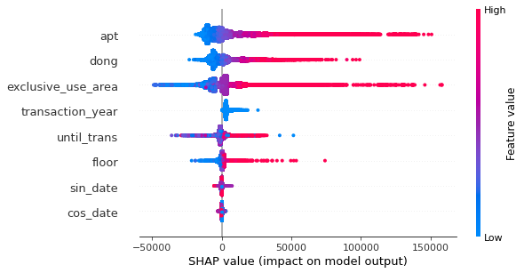

```python
shap.summary_plot(shap_values)
```

## 2. 딥러닝 기본

딥러닝 정말 간단히 해볼겁니다!

### 2.1 주어진 코드를 실행하고, 현재 신경망의 구조에 대해 간단히 설명해주세요.

```python
train = pd.read_csv('C:/Users/user/Downloads/주제분석 3주차 패키지/train.csv')
train_x = train.drop(['price'], axis = 1)
train_y = train.loc[:, ['price']]

val_x = train_x[train['transaction_year'] == 4]
val_y = train_y[train['transaction_year'] == 4]
train_tune_x = train_x[train['transaction_year'] < 4]
train_tune_y = train_y[train['transaction_year'] < 4]

CBE_encoder = CatBoostEncoder()
train_tune_cbe = CBE_encoder.fit_transform(train_tune_x[feature_list], train_tune_y)
val_cbe = CBE_encoder.transform(val_x[feature_list])
```

```python
import tensorflow as tf
import keras

from keras import models
from keras import layers
from keras.layers import Dense
from keras.optimizers import Adam
```

```python
def build_model():
  model = keras.Sequential([
    layers.Dense(256, activation='relu', input_shape=[len(train_tune_cbe.keys())]),
    layers.Dense(64, activation='relu'),
    layers.Dense(32, activation='relu'),
    layers.Dense(1)
  ])

  optimizer = tf.keras.optimizers.RMSprop(0.0001)

  model.compile(loss='mse',
                optimizer=optimizer,
                metrics=['mse'])
  return model
```

```python
model = build_model()
model.summary()
```

```
Model: "sequential"
_________________________________________________________________
Layer (type)                 Output Shape              Param #
=================================================================
dense (Dense)                (None, 256)               2304
_________________________________________________________________
dense_1 (Dense)              (None, 64)                16448
_________________________________________________________________
dense_2 (Dense)              (None, 32)                2080
_________________________________________________________________
dense_3 (Dense)              (None, 1)                 33
=================================================================
Total params: 20,865
Trainable params: 20,865
Non-trainable params: 0
_________________________________________________________________
```

### 2.2 training loss와 validation loss를 시각화하세요.

- 본인 컴에서 돌리면 꽤나 돌아갈수도 있어요. 주분과 함께하려면 패키지가 코랩으로 가거나, 주분이 코랩으로 가면 한번에 투 컴을 돌릴 수 있습니다.

```python
history = model.fit(train_tune_cbe, train_tune_y, epochs=300, validation_data = (val_cbe, val_y), batch_size = 512)

# al_mse: 282948544.0000
# - val_mse: 315550720.0000
```

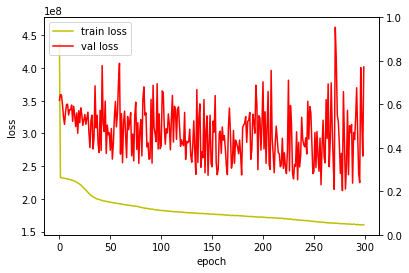

```python
# 5. 모델 학습 과정 표시하기
fig, loss_ax = plt.subplots()

acc_ax = loss_ax.twinx()

loss_ax.plot(history.history['loss'], 'y', label='train loss')
loss_ax.plot(history.history['val_loss'], 'r', label='val loss')

loss_ax.set_xlabel('epoch')
loss_ax.set_ylabel('loss')


loss_ax.legend(loc='upper left')


plt.show()
```

### 2.3 어떤문제가 발생했는지 설명해주세요.

- 꼭 써주세요.

valoss가 수렴하지 않아서 결국 거의 줄어들지 않았습니다.

- 이전에 lgbm 같은 경우 validation mse가 $1.2 * 10^8$ 이였습니다.

### 2.4 더 좋은 성능의 딥러닝 모델을 위해

- test set에 대해 딥러닝 모형의 성능을 평가하세요.
- dense 조절, batch_size 조절, regularization, dropout, batch normalization 등의 방법을 활용해 최고의 성능을 얻어보세요.
- 만약 성능의 향상이 어렵다면, 다양한 방법들을 시도하는 것을 목표로 해주세요!

최종적으로 딥러닝 결과 mse가 2637878834.1185493 으로 나와서 lgbm보다 성능이 떨어지는 것 같습니다.

```python
feature_list = list(train_x.columns)

CBE_encoder = CatBoostEncoder()
train_cbe = CBE_encoder.fit_transform(train_x[feature_list], train_y)
test_cbe = CBE_encoder.transform(test_x[feature_list])
```

```python
pred = model.predict(test_cbe)
```

```python
#rmse
import math
from sklearn.metrics import mean_squared_error
mean_squared_error(test_y, pred)
```

```
2637878834.1185493
```

## 튜닝 -grid search실패

```python
# from sklearn.model_selection import GridSearchCV
```

```python
# seed = 42
# np.random.seed(seed)
# batch_size = 512
# epochs = 300
# #
# batch_size = [10, 20, 40, 60, 80, 100]
# epochs = [10, 50, 100]
# param_grid = dict(batch_size=batch_size, epochs=epochs)
# grid = GridSearchCV(estimator=model, param_grid=param_grid, scoring ='accuracy', n_jobs=-1, cv=3)
# # grid_result = grid.fit(train_cbe,train_y) ->  error
```

```python
# grid_result.cv_results_
```

## tuning 수작업...

```python
history2 = model.fit(train_tune_cbe, train_tune_y, epochs=100, validation_data = (val_cbe, val_y), batch_size = 512)
```

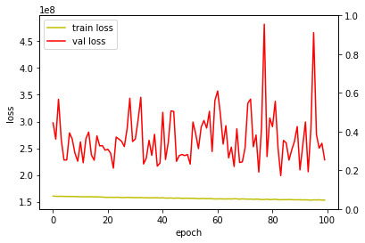

```python
# 5. 모델 학습 과정 표시하기
fig, loss_ax = plt.subplots()

acc_ax = loss_ax.twinx()

loss_ax.plot(history2.history['loss'], 'y', label='train loss')
loss_ax.plot(history2.history['val_loss'], 'r', label='val loss')

loss_ax.set_xlabel('epoch')
loss_ax.set_ylabel('loss')


loss_ax.legend(loc='upper left')


plt.show()
```

```python
history3 = model.fit(train_tune_cbe, train_tune_y, epochs=300, validation_data = (val_cbe, val_y), batch_size = 100)
```

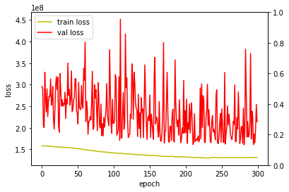

```python
# 5. 모델 학습 과정 표시하기
fig, loss_ax = plt.subplots()

acc_ax = loss_ax.twinx()

loss_ax.plot(history3.history['loss'], 'y', label='train loss')
loss_ax.plot(history3.history['val_loss'], 'r', label='val loss')

loss_ax.set_xlabel('epoch')
loss_ax.set_ylabel('loss')


loss_ax.legend(loc='upper left')


plt.show()
```

```python
history4 = model.fit(train_tune_cbe, train_tune_y, epochs=1000, validation_data = (val_cbe, val_y), batch_size = 600)
```

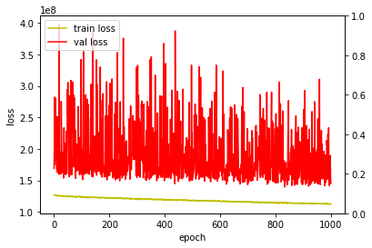

```python
# 5. 모델 학습 과정 표시하기
fig, loss_ax = plt.subplots()

acc_ax = loss_ax.twinx()

loss_ax.plot(history4.history['loss'], 'y', label='train loss')
loss_ax.plot(history4.history['val_loss'], 'r', label='val loss')

loss_ax.set_xlabel('epoch')
loss_ax.set_ylabel('loss')


loss_ax.legend(loc='upper left')


plt.show()
```